# Week02 Assignment

Sophie Kim

February 13, 2016

# 1. Some human phenotypic distributions

1.1 Loading in data

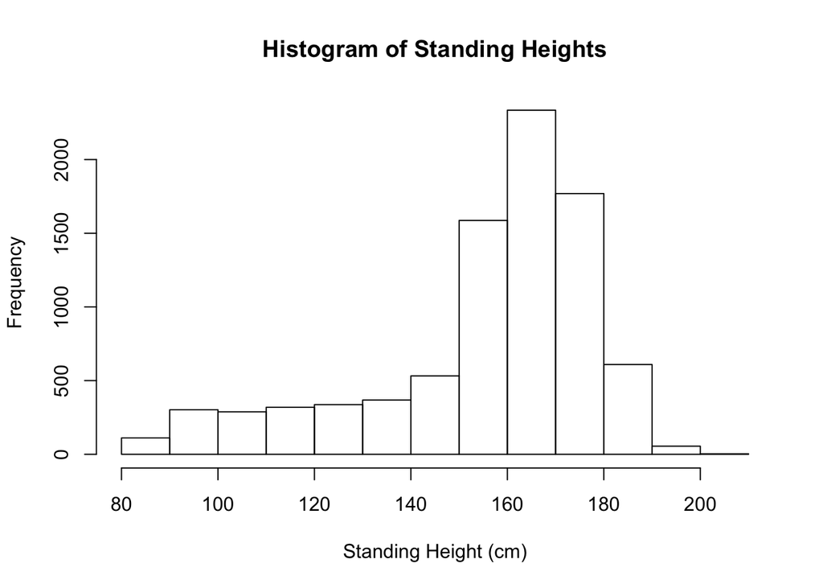

```r
bmxData <- read.delim("bmx.tsv")

hist(bmxData$BMXHT, main = "Histogram of Standing Heights", xlab = "Standing Height (cm)", ylab = "Frequency")
```

*the variable BMXHT measures the standing height in cm.

# 2. Chi-square test

2.1 Setting up for Mendelian

- Reading the data

```r
mendelData <- read.delim("mendel.tab")
```

- Functions to calculate expected values and chi square statistics

```r
getExp <- function(proportion, n) {
  expected <- proportion*n
  return (expected)
}

calChi <- function(observed, expected) {
  result <- ((observed - expected)^2)/expected
  return (result)
}



mainCalc <- function(tasknum) {
  n <- mendelData[tasknum, "F2.counts.1st.phenotype"] + mendelData[4, "F2.counts.2nd.phenotype"]

  observed1 <- mendelData[tasknum, "F2.counts.1st.phenotype"]
  expected1 <- getExp(0.5, n)
  chi1 <- calChi(observed1, expected1)

  observed2 <- mendelData[tasknum, "F2.counts.2nd.phenotype"]
  expected2 <- getExp(0.5, n)
  chi2 <- calChi(observed2, expected2)
  return (chi1 + chi2)
}
```

1. Round X Wrinkled Seeds

```r
chiSum1 <- mainCalc(1)
chiSum1
```

```
## [1] 2691.664
```

```r
pchisq(chiSum1, 1)
```

```
## [1] 1
```

2. Yellow X Green Seeds

```r
chiSum2 <- mainCalc(2)
chiSum2
```

```
## [1] 3016.175
```

```r
pchisq(chiSum2, 1)
```

```
## [1] 1
```

3. Purple X White Seeds

```r
chiSum3 <- mainCalc(3)
chiSum3
```

```
## [1] 236.0418
```

```r
pchisq(chiSum3, 1)
```

```
## [1] 1
```

4. Inflated X Pinched Pods

```r
chiSum4 <- mainCalc(4)
chiSum4
```

```
## [1] 287.7976
```

```r
pchisq(chiSum4, 1)
```

```
## [1] 1
```

5. Green X Yellow Pods

```r
chiSum5 <- mainCalc(5)
chiSum5
```

```
## [1] 134.5048
```

```r
pchisq(chiSum5, 1)
```

```
## [1] 1
```

6. Axial X Terminal Flowers

```r
chiSum6 <- mainCalc(6)
chiSum6
```

```
## [1] 216.4211
```

```r
pchisq(chiSum6, 1)
```

```
## [1] 1
```

7. Long X Short Stems

```r
chiSum7 <- mainCalc(7)
chiSum7
```

```
## [1] 239.9484
```

```r
pchisq(chiSum7, 1)
```

```
## [1] 1
```

2.2 3:1 ratios

- Functions to calculate expected values and chi square statistics

```r
getExp <- function(proportion, n) {
  expected <- proportion*n
  return (expected)
}

calChi <- function(observed, expected) {
  result <- ((observed - expected)^2)/expected
  return (result)
}



mainCalc <- function(tasknum) {
  n <- mendelData[tasknum, "F2.counts.1st.phenotype"] + mendelData[4, "F2.counts.2nd.phenotype"]

  observed1 <- mendelData[tasknum, "F2.counts.1st.phenotype"]
  expected1 <- getExp(0.75, n)
  chi1 <- calChi(observed1, expected1)

  observed2 <- mendelData[tasknum, "F2.counts.2nd.phenotype"]
  expected2 <- getExp(0.25, n)
  chi2 <- calChi(observed2, expected2)
  return (chi1 + chi2)
}
```

1. Round X Wrinkled Seeds

```r
chiSum1 <- mainCalc(1)
chiSum1
```

```
## [1] 417.0321
```

```r
pchisq(chiSum1, 1)
```

```
## [1] 1
```

2. Yellow X Green Seeds

```r
chiSum2 <- mainCalc(2)
chiSum2
```

```
## [1] 458.3016
```

```r
pchisq(chiSum2, 1)
```

```
## [1] 1
```

3. Purple X White Seeds

```r
chiSum3 <- mainCalc(3)
chiSum3
```

```
## [1] 5.964143
```

```r
pchisq(chiSum3, 1)
```

```
## [1] 0.9854003
```

4. Inflated X Pinched Pods

```r
chiSum4 <- mainCalc(4)
chiSum4
```

```
## [1] 0.0635055
```

```r
pchisq(chiSum4, 1)
```

```
## [1] 0.1989612
```

5. Green X Yellow Pods

```r
chiSum5 <- mainCalc(5)
chiSum5
```

```
## [1] 30.08299
```

```r
pchisq(chiSum5, 1)
```

```
## [1] 1
```

6. Axial X Terminal Flowers

```r
chiSum6 <- mainCalc(6)
chiSum6
```

```
## [1] 9.225263
```

```r
pchisq(chiSum6, 1)
```

```
## [1] 0.997613
```

7. Long X Short Stems

```r
chiSum7 <- mainCalc(7)
chiSum7
```

```
## [1] 1.039902
```

```r
pchisq(chiSum7, 1)
```

```
## [1] 0.6921557
```

2.3 Some more Mendelian Genetics

Imagine a cross between two diploid individuals heterozygous for ten independently assorting Mendelian traits.

1. What is the probability of one of their progeny being homozygous recessive for all traits?

```r
(1/16)^10
```

```
## [1] 9.094947e-13
```

2)What is the probability of a progeny that is homozygous dominant for all traits?

```r
(1/16)^10
```

```
## [1] 9.094947e-13
```

# 3. and Bateson et al observe coupling

1. Reading Bateson tab data

```r
bData <- read.delim("bateson.tab", header = FALSE)
```

- factors: shape, color
- levels: purple, red, long, round
- degrees of freedom = 1

```r
calChi <- function(observed, expected) {
  result <- ((observed - expected)^2)/expected
  return (result)
}

n <- sum(bData[,2])

purple <- bData[1,2] + bData[3,2]
long <- bData[1,2] + bData[1,2]
red <- bData[2,2] + bData[4,2]
round <- bData[2,2] + bData[4,2]

PL <- (purple*long)/n
pL <- (red*long)/n
Pr <- (purple*round)/n
pr <- (red*round)/n

chisquareSum <- calChi(bData[1,2], PL) + calChi(bData[2,2], pL) + calChi(bData[3,2], Pr) + calChi(bData[4,2], pr)

chisquareSum
```

```
## [1] 1583.359
```

*there was a minor type-o in accessing the bData[1,2]